# cc_data_cleaning_revised

**Project Overview**

This notebook documents the steps our team has taken to clean and prepare the credit card dataset (`cc_data`). The cleaning process ensures that the dataset is consistent, reliable, and ready for subsequent analysis such as customer segmentation and predictive modeling.

Key objectives of this notebook include:

- Identifying and handling missing values
- Evaluating skewness to guide imputation strategy
- Ensuring data integrity by checking for duplicates

The work reflects a collaborative effort by the project team to establish a robust data foundation for downstream tasks.

**Table of Contents**

1. Data Quality Checks
   - Missing Values Analysis
   - Imputation Strategy (Credit Limit & Minimum Payments)
2. Data Integrity Checks
   - Duplicate Records

|  | CUST_ID | BALANCE | BALANCE_FREQUENCY | PURCHASES | ONEOFF_PURCHASES | INSTALLMENTS_PURCHASES | CASH_ADVANCE | PURCHASES_FREQUENCY | ONEOFF_PURCHASES_FREQUENCY | PURCHASES_INSTALLMENTS_FREQUENCY | CASH_ADVANCE_FREQUENCY | CASH_ADVANCE_TRX | PURCHASES_TRX | CREDIT_LIMIT | PAYMENTS | MINIMUM_PAYMENTS | PRC_FULL_PAYMENT | TENURE |
| --- | --- | --- | --- | --- | --- | --- | --- | --- | --- | --- | --- | --- | --- | --- | --- | --- | --- | --- |
| 0 | C10001 | 40.900749 | 0.818182 | 95.40 | 0.00 | 95.4 | 0.000000 | 0.166667 | 0.000000 | 0.083333 | 0.000000 | 0 | 2 | 1000.0 | 201.802084 | 139.509787 | 0.000000 | 12 |
| 1 | C10002 | 3202.467416 | 0.909091 | 0.00 | 0.00 | 0.0 | 6442.945483 | 0.000000 | 0.000000 | 0.000000 | 0.250000 | 4 | 0 | 7000.0 | 4103.032597 | 1072.340217 | 0.222222 | 12 |
| 2 | C10003 | 2495.148862 | 1.000000 | 773.17 | 773.17 | 0.0 | 0.000000 | 1.000000 | 1.000000 | 0.000000 | 0.000000 | 0 | 12 | 7500.0 | 622.066742 | 627.284787 | 0.000000 | 12 |
| 3 | C10004 | 1666.670542 | 0.636364 | 1499.00 | 1499.00 | 0.0 | 205.788017 | 0.083333 | 0.083333 | 0.000000 | 0.083333 | 1 | 1 | 7500.0 | 0.000000 | NaN | 0.000000 | 12 |
| 4 | C10005 | 817.714335 | 1.000000 | 16.00 | 16.00 | 0.0 | 0.000000 | 0.083333 | 0.083333 | 0.000000 | 0.000000 | 0 | 1 | 1200.0 | 678.334763 | 244.791237 | 0.000000 | 12 |

```
<class 'pandas.core.frame.DataFrame'>
RangeIndex: 8950 entries, 0 to 8949
Data columns (total 18 columns):
 #   Column                            Non-Null Count  Dtype
---  ------                            --------------  -----
 0   CUST_ID                           8950 non-null   object
 1   BALANCE                           8950 non-null   float64
 2   BALANCE_FREQUENCY                 8950 non-null   float64
 3   PURCHASES                         8950 non-null   float64
 4   ONEOFF_PURCHASES                  8950 non-null   float64
 5   INSTALLMENTS_PURCHASES            8950 non-null   float64
 6   CASH_ADVANCE                      8950 non-null   float64
 7   PURCHASES_FREQUENCY               8950 non-null   float64
 8   ONEOFF_PURCHASES_FREQUENCY        8950 non-null   float64
 9   PURCHASES_INSTALLMENTS_FREQUENCY  8950 non-null   float64
 10  CASH_ADVANCE_FREQUENCY            8950 non-null   float64
 11  CASH_ADVANCE_TRX                  8950 non-null   int64
 12  PURCHASES_TRX                     8950 non-null   int64
 13  CREDIT_LIMIT                      8949 non-null   float64
 14  PAYMENTS                          8950 non-null   float64
 15  MINIMUM_PAYMENTS                  8637 non-null   float64
 16  PRC_FULL_PAYMENT                  8950 non-null   float64
 17  TENURE                            8950 non-null   int64
dtypes: float64(14), int64(3), object(1)
memory usage: 1.2+ MB
```

As a team, we begin by examining the dataset for missing values to ensure data completeness before proceeding with further analysis.

```
CUST_ID                             0.000000
BALANCE                             0.000000
BALANCE_FREQUENCY                   0.000000
PURCHASES                           0.000000
ONEOFF_PURCHASES                    0.000000
INSTALLMENTS_PURCHASES              0.000000
CASH_ADVANCE                        0.000000
PURCHASES_FREQUENCY                 0.000000
ONEOFF_PURCHASES_FREQUENCY          0.000000
PURCHASES_INSTALLMENTS_FREQUENCY    0.000000
CASH_ADVANCE_FREQUENCY              0.000000
CASH_ADVANCE_TRX                    0.000000
PURCHASES_TRX                       0.000000
CREDIT_LIMIT                        0.011173
PAYMENTS                            0.000000
MINIMUM_PAYMENTS                    3.497207
PRC_FULL_PAYMENT                    0.000000
TENURE                              0.000000
dtype: float64
```

Our review shows that the `CREDIT_LIMIT` column has ~0.011% missing values and the `MINIMUM_PAYMENTS` column has ~3.5%. Given these relatively low proportions, the team agreed to proceed with imputation rather than discarding records.

```
Skewness: 1.52
Mean: 4494.45
Median: 3000.00
```

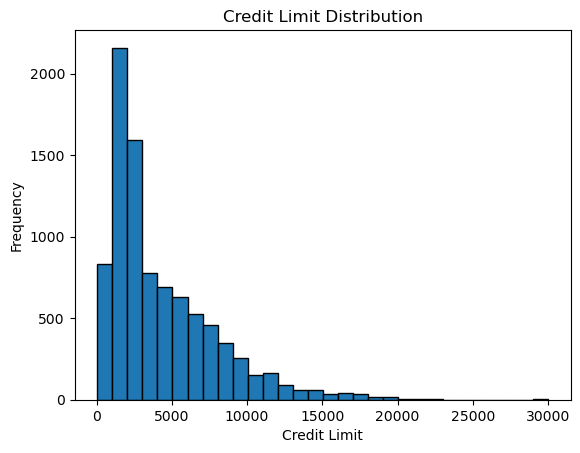

Next, the team evaluates the skewness of the `CREDIT_LIMIT` distribution to decide whether the mean or median provides a more reliable imputation. This step ensures that imputed values better represent the overall distribution.

**Interpretation note (reframed for team):**

- **≈ 0** → Distribution is symmetrical → Either mean or median is appropriate.
- **> 0.5** → Moderately right-skewed → Median is more robust.
- **> 1** → Strongly right-skewed → Median is recommended.
- **< -0.5** → Left-skewed → Mean may be acceptable, but requires caution.

Based on the team’s findings, the `CREDIT_LIMIT` distribution is strongly right-skewed (skewness > 1). Therefore, we chose the median for imputation to minimize the impact of outliers.

```
Skewness: 13.62
Mean: 864.21
Median: 312.34
```

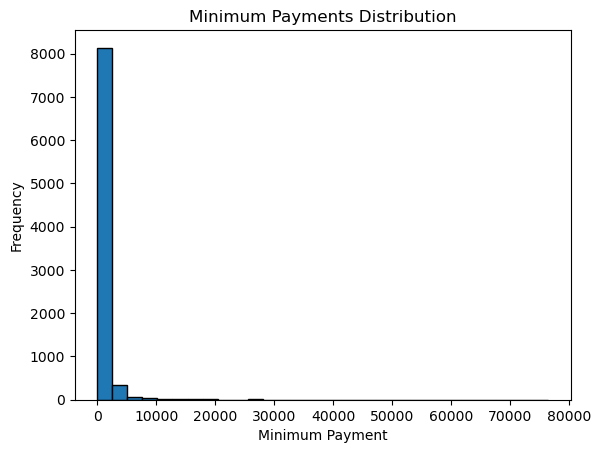

The team then performs a skewness analysis on the `MINIMUM_PAYMENTS` column to evaluate whether the median or mean is the best fit for imputation.

(Same interpretation rules as before apply here.)

Our analysis shows the `MINIMUM_PAYMENTS` column is also strongly right-skewed. As a result, the team decided to impute missing values using the median to better represent the dataset’s central tendency.

```
Number of duplicate rows: 0
```

Finally, the team performed a duplicate check across all records. No duplicates were detected, confirming data integrity at this stage.